This project analyzes data from accelerometers on the belt, forearm, arm, and dumbell of 6 exercise participants. Each participant was asked to perform barbell lifts correctly and incorrectly in 5 different ways. More information is available from the website here: http://groupware.les.inf.puc-rio.br/har (see the section on the Weight Lifting Exercise Dataset).

The data includes a test and training set. The training set has a “classe” variable which gives the predicted result (5 levels of “correct” to “incorrect”), along with a large number of input variables giving the accelerometer values and other data for each reading. The test set contains 20 readings, with input variables but no predicted result.

To determine a good model to fit the data, we tried a number of approaches, including generalized linear models for multinomial data (glmnet), random forests, and multinomial models including those from the mnet and mlogit packages. Based on these tests, random forests appeared to give the best results.

Our first task is to clean the data, as there are columns with many NA values and also #DIV/0 values. We elected to remove these columns, as there are still a large number of columns in the data set. There were also a number of columns which are not useful as predictors, such as user name and time stamps. We eliminate these columns from the data set as well.

```r
train <- read.csv("pml-training.csv") # load the training and test sets
test <- read.csv("pml-testing.csv")
train2 <- train[,colSums(is.na(train)) == 0] # get rid of columns with NA values
test2 <- test[,colSums(is.na(test)) == 0]
out = c() # get rid of columns with "#DIV/0!" values
for (i in 1:ncol(train2)) {
  if (any(train2[,i] == '#DIV/0!'))
    out = c(out,i)
}
train3 <- train2[,-out]
ytrain = train3[,60] # select outcome (y) and predictors (x's)
xtrain = train3[,-60]
ytest = test2[,60]
xtest = test2[,-60]
# eliminate X index, user name, time stamps, new window y/n, and num_window, as these
# don't make sense as predictors
xtrain2 <- xtrain[,c(-1:-7)]
xtest2 <- xtest[,c(-1:-7)]
```

```r
library(caret)
library(randomForest)
```

```r
idx <- createFolds(ytrain, k=5) # Cross validation
cvx = list()
cvy = list()
cvx[[1]] <- xtrain2[-1*(idx$Fold1),]
cvx[[2]] <- xtrain2[-1*(idx$Fold2),]
cvx[[3]] <- xtrain2[-1*(idx$Fold3),]
cvx[[4]] <- xtrain2[-1*(idx$Fold4),]
cvx[[5]] <- xtrain2[-1*(idx$Fold5),]
cvy[[1]] <- ytrain[-1*(idx$Fold1)]
cvy[[2]] <- ytrain[-1*(idx$Fold2)]
cvy[[3]] <- ytrain[-1*(idx$Fold3)]
cvy[[4]] <- ytrain[-1*(idx$Fold4)]
cvy[[5]] <- ytrain[-1*(idx$Fold5)]
cvmod = list()
cvpred = list()
cvaccr = list()
for (i in 1:5) { # for each fold, build model, predict on remaining values, and get error
  cvmod[[i]] <- randomForest(cvx[[i]],cvy[[i]],ntree=10)
  cvpred[[i]] <- predict(cvmod[[i]], as.matrix(cvx[[i]]))
  cvaccr[[i]] <- sum(cvpred[[i]] == cvy[[i]])/length(cvy[[i]])
}
```

We next build a model based on the entire training set. The confusion matrix shows that the model predicts the training set well:

```r
model <- randomForest(xtrain2,ytrain,ntree=10) # train on whole training set
pred <- predict(model, as.matrix(xtrain2))
accr <- sum(pred == ytrain)/length(ytrain)
model$confusion
```

```
##      A    B    C    D    E class.error
## A 5432   44   16   28    7  0.01718835
## B   60 3588   66   27   28  0.04802335
## C   18   74 3224   51   16  0.04699970
## D   11   16   65 3058   23  0.03624330
## E   12   30   23   17 3484  0.02299495
```

And the following plot shows the error rates dropping as more trees are added to the random forest model:

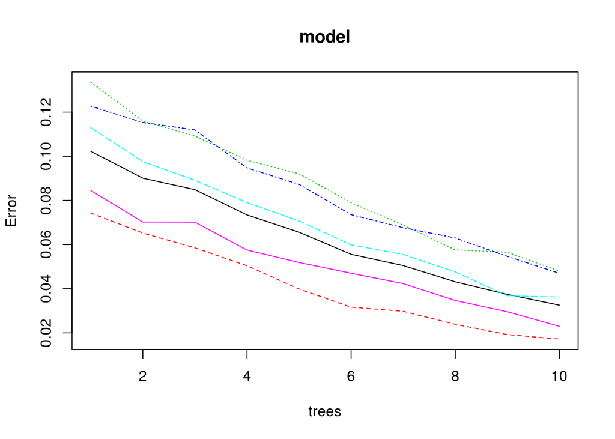

```r
plot(model)
```

We lastly use the model to predict the outcome for the 20 rows of the test set:

```r
pred2 <- predict(model, as.matrix(xtest2)) # predict based on testing set
pred2
```

```
##  1  2  3  4  5  6  7  8  9 10 11 12 13 14 15 16 17 18 19 20
##  B  A  B  A  A  E  D  B  A  A  B  C  B  A  E  E  A  B  B  B
## Levels: A B C D E
```